# Chapter 3: A Closer Look at Assumptions

Loren

08/18/2014

# Chapter 3: A Closer Look at Assumptions

## This chapter's examples

### Cloud Seeding

On 52 days, clouds were either seeded or not (randomly decided), and rainfall was recorded. There were an equal number of days in each treatment group.

```r
##
##   SEEDED UNSEEDED
##       26       26
```

The data are skewed:

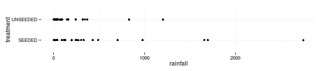

A log transform seems to give normally-distributed data of approximately equal spreads:

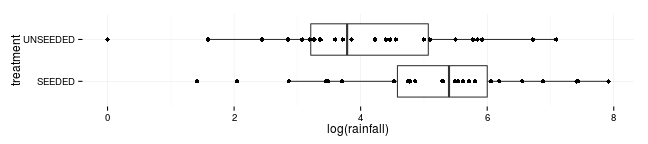

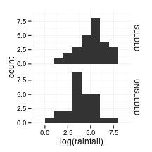

The log-transformed data fulfills the assumptions of a t-test:

```r
##
##  Two Sample t-test
##
## data:  log(rainfall) by treatment
## t = 2.544, df = 50, p-value = 0.01408
## alternative hypothesis: true difference in means is not equal to 0
## 95 percent confidence interval:
##  0.2409 2.0467
## sample estimates:
##   mean in group SEEDED mean in group UNSEEDED
##                  5.134                  3.990
```

The additive effect on log(rainfall) (from UNSEEDED to SEEDED) is 1.1438, so the multiplicative effect on rainfall itself is 3.1386. The 95% confidence interval for the ratio of SEEDED to UNSEEDED is (1.2723, 7.7423).

### Agent orange

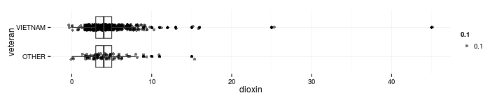

The two groups seem to have approximately the same standard deviation.

```r
## veteran: OTHER
## [1] 2.302
## --------------------------------------------------------
## veteran: VIETNAM
## [1] 2.643
```

There are zeroes in the dataset, so taking a log directly does not make sense. The `vietnam` group is much larger, so we should expect a larger range in that group.

## Conceptual Exercises

### 20 Means, Medians, Logs, Ratios

Here is some made-up data on college tuition:

```r
##   college outofstate instate
## 1       a       3000    1000
## 2       b       8000    4000
## 3       c      30000    5000
## 4       d      32000    8000
## 5       e      40000   40000
```

a) The average in-state tuition is 1.16 × 10<sup>4</sup>. The average of log-instate is 8.6606. The log of the average instate is 9.3588.

b) These two are the same:

```r
## [1] 8.517
```

```r
## [1] 8.517
```

The median of the ratios is **not** the same as the ratio of the medians:

```r
## [1] 3
```

```r
## [1] 6
```

## Computational Exercises

### 21. Umpires and Life-Expectancy

The study asks whether umpires live shorter than expected. 32 of the umpires in the data had not died at the time of the study, so their lifelength was not known. The original study 'censored' their data. A t-test on non-censored data looks like this:

```r
##
##  One Sample t-test
##
## data:  expected - lifelength
## t = 0.987, df = 194, p-value = 0.3249
## alternative hypothesis: true mean is not equal to 0
## 95 percent confidence interval:
##  -0.5375  1.6144
## sample estimates:
## mean of x
##    0.5385
```

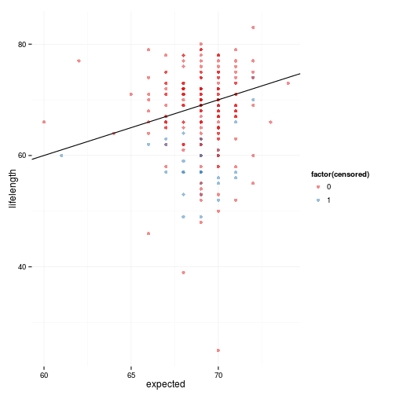

### 22. Voltage and Insulating Fluid

```r
##   kV    time
## 1 26    5.79
## 2 26 1579.52
## 3 26 2323.70
## 4 28   68.80
## 5 28  108.29
## 6 28  110.29
## 7 28  426.07
## 8 28 1067.60
```

### 23. Solar Radiation and Skin Cancer

```r
##   year rate sunspot
## 1 1938  0.8     LOW
## 2 1939  1.3    HIGH
## 3 1940  1.4    HIGH
## 4 1941  1.2    HIGH
## 5 1942  1.7     LOW
## 6 1943  1.8     LOW
```

1. TODO
2. In the following plot, high-sunspot years are almost all above the regression line. Low-sunspot years are almost all below the line. There is an upward trend in both groups. Does this mean that the observations aren't independent? Would this make the test sensitive to the choice of what years to start and end at?

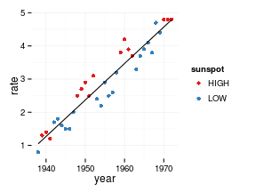

### 24. Sex Discrimination revisited with logs

The data don't look skewed, so I'm not sure why they're having me do this.

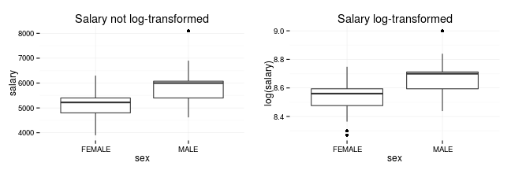

```r
##
##  Welch Two Sample t-test
##
## data:  log(salary) by sex
## t = -6.054, df = 59.81, p-value = 1.009e-07
## alternative hypothesis: true difference in means is not equal to 0
## 95 percent confidence interval:
##  -0.19550 -0.09839
## sample estimates:
## mean in group FEMALE   mean in group MALE
##                8.539                8.686
```

P-value = 1.0087 × 10<sup>-7</sup>. The 95% confidence interval for the *difference in logs* is (-0.1955, -0.0984). The 95% confidence interval for the *ratio of medians* is (0.8224, 0.9063).

### 25. Agent orange and outliers

The one-sided p-value of a t-test, without removing any points or transforming the data, is 0.3963. After removing the highest two points, the p-value is 0.5386.

### 26. Agent orange, log-transformed

Here are boxplots of log(dioxin + 0.5):

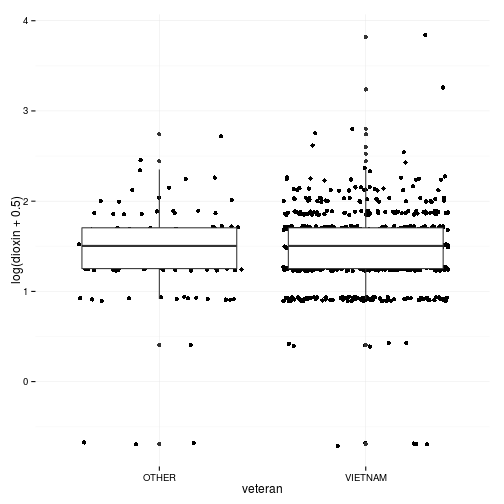

The 2-sided p-value of a t-test on the transformed variable is 0.3816. A confidence interval (approximate because of the added 0.5) for the ratio of medians is (0.8684, 1.0556). That's median(other)/median(vietnam).

### 30. Cloud seeding: multiplicative vs. additive effects

Adding 100, 200, 300, and 400 to the unseeded rainfalls, and plotting the result:

[figure not shown]

Viewed in the context of these graphs, the effect 'looks' multiplicative.

Styled with knitrBootstrap